# Тема “Применение авторегрессионной модели с распределенными лагами ARDL для определение факторов и степени их влияния на приток прямых иностранных инвестиций в страны Ближнего Востока”

## Аннотация

В данной статье рассматривается применение авторегрессионной модели с распределенными лагами (ARDL) для анализа факторов, влияющих на приток прямых иностранных инвестиций (ПИИ) в страны Ближнего Востока. Используя данные о ПИИ, ВВП, ВВП на душу населения, продолжительности жизни, уровне иммунизации, объеме торговли товарами, индексе потребительских цен и политической стабильности, модель ARDL позволила исследовать краткосрочные и долгосрочные взаимосвязи между этими переменными и притоком ПИИ.

Результаты моделирования показывают значительное влияние как текущих, так и прошлых значений исследуемых факторов на приток ПИИ в регион. В частности, было обнаружено, что увеличение ВВП и ВВП на душу населения в предыдущем периоде положительно сказывается на притоке ПИИ, тогда как увеличение индекса потребительских цен и политической стабильности в прошлом оказывает отрицательное влияние. Также выявлено негативное воздействие прошлых значений притока ПИИ на его текущий уровень, что может указывать на насыщение рынка или изменение инвестиционного климата.

Статья вносит вклад в понимание динамики ПИИ в странах Ближнего Востока, предоставляя ценные данные для политиков и инвесторов, стремящихся оптимизировать условия для привлечения иностранного капитала. Полученные результаты подчеркивают значимость экономического роста, стабильности цен и политической ситуации в регионе для стимулирования притока ПИИ.

## Ключевые слова

Авторегрессионная модель с распределенными лагами, Ближний Восток, прямые иностранные инвестиции, ВВП, ВВП на душу населения, продолжительность жизни, уровнь иммунизации, объем торговли товарами, индекс потребительских цен, индекс политической стабильности.

## Введение

Приток прямых иностранных инвестиций (ПИИ) на Ближний Восток исторически является предметом обширных исследований из-за его значительного влияния на экономическое развитие и стабильность региона. Поскольку страны Ближнего Востока продолжают диверсифицировать свои экономики и уменьшать зависимость от доходов от нефти, понимание факторов, влияющих на приток ПИИ, становится все более важным. Модель авторегрессии с распределенным лагом (ARDL) выступает в этом контексте мощным эконометрическим инструментом, предлагая тонкий подход к изучению долгосрочной и краткосрочной динамики между притоками ПИИ и их детерминантами на Ближнем Востоке. В данной статье рассматривается применение модели ARDL для идентификации и анализа этих влиятельных факторов, предоставляя ценные взгляды для политиков, инвесторов и ученых, заинтересованных в экономическом процветании региона.

Методика ARDL, представленная Pesaran et al. (2001), выделяется своей гибкостью в обращении с переменными, интегрированными на разных уровнях, что делает ее особенно подходящей для исследований ПИИ, где свойства базовых данных сложны. Способность модели оценивать как коэффициенты долгосрочного периода, так и динамику краткосрочного периода одновременно предлагает полное представление о взаимодействии между притоками ПИИ и потенциальными объясняющими переменными, такими как политическая стабильность, экономический рост, размер рынка, стоимость рабочей силы и открытость торговли на Ближнем Востоке.

Значение Ближнего Востока как направления для ПИИ не может быть переоценено. Стратегическое географическое положение региона, наряду с значительными запасами природных ресурсов и недавними экономическими реформами, делает его привлекательной ареной для международных инвесторов. Однако геополитические сложности и усилия по диверсификации экономики представляют многоаспектный ландшафт для притока ПИИ. Таким образом, использование модели ARDL для раскрытия этих сложностей предоставляет методологическое преимущество, позволяя исследователям уловить как немедленные, так и задержанные эффекты различных факторов на ПИИ.

Предыдущие исследования выделили несколько ключевых детерминант притока ПИИ на Ближний Восток, включая, но не ограничиваясь этим, экономические политики, нормативные рамки, политическую стабильность и региональные конфликты (Ali, Al-Sadig, 2013; Asiedu, 2002). Применение модели ARDL в этом контексте позволяет провести детальное исследование этих детерминантов, учитывая уникальные экономические и политические характеристики региона. Например, модель может помочь установить влияние недавних экономических реформ в странах, таких как Саудовская Аравия и Объединенные Арабские Эмираты, на привлечение ПИИ, учитывая краткосрочные корректировки и долгосрочные взаимосвязи.

Кроме того, рамки ARDL облегчают исследование роли развития инфраструктуры, инновационного потенциала и человеческого капитала в привлечении ПИИ на Ближний Восток. Эти факторы особенно актуальны, учитывая усилия региона по диверсификации экономики и переходу к экономикам, основанным на знаниях. Используя модель ARDL, исследователи могут предоставить эмпирические доказательства эффективности таких инициатив в повышении привлекательности региона для иностранных инвесторов.

Раздел методологии этой статьи подробно описывает спецификации модели ARDL, источники данных и обоснование выбора переменных, обеспечивая надежный и прозрачный анализ. Раздел эмпирических результатов представляет результаты оценок ARDL, выделяя как краткосрочные, так и долгосрочные детерминанты притока ПИИ на Ближний Восток. Это будет включать обсуждение роли экономических переменных, таких как ВВП,ВВП на душу населения, инфляция и доля торговли товарами от ВВП, а также неэкономических факторов, таких как политическая стабильность, продолжительность жизни при рождении и доля вакцинированного населения.

Применение модели ARDL для изучения факторов, влияющих на приток ПИИ на Ближний Восток, предлагает всеобъемлющую аналитическую рамку, которая учитывает экономические и политические нюансы региона. Эта статья стремится внести вклад в существующую литературу, предоставив подробный эмпирический анализ с использованием подхода ARDL, тем самым предлагая практические рекомендации для политиков, стремящихся повысить привлекательность Ближнего Востока для иностранных инвесторов. Через это исследование мы стремимся подчеркнуть важность стабильной и благоприятной инвестиционной среды, поддерживаемой здравыми экономическими политиками и реформами, для привлечения устойчивого притока ПИИ в регион.

## Обзор литературы

Обзор литературы на тему применения авторегрессионной модели с распределенными лагами (ARDL) для анализа факторов, влияющих на приток прямых иностранных инвестиций (ПИИ) в страны Ближнего Востока, иллюстрирует разнообразие подходов и результатов предыдущих исследований. Значимость и сложность данной тематики обусловливаются экономическими, социальными и политическими особенностями региона. В данном обзоре рассматриваются основные работы, охватывающие взаимосвязь между объемом притока ПИИ и выбранными независимыми переменными: ВВП, ВВП на душу населения, ожидаемой продолжительностью жизни, уровнем иммунизации, торговлей товарами, индексом потребительских цен (ИПЦ), а также политической стабильностью.

Факторы, перечисленные выше, оказывают существенное воздействие на приток прямых иностранных инвестиций (ПИИ) по следующим причинам:

1. **ВВП и ВВП на душу населения**: Валовой внутренний продукт отражает общую экономическую активность страны, а более высокий ВВП свидетельствует о большем рыночном потенциале, представляющем интерес для иностранных инвесторов (Pham, M. H., Pham, A., & Dang, C. V. P., 2023). ВВП на душу населения индицирует уровень дохода и потребительской способности населения, что также стимулирует привлечение инвестиций.
2. **Ожидаемая продолжительность жизни**: Этот показатель часто используется в качестве индикатора здоровья нации и благосостояния населения. Более высокая ожидаемая продолжительность жизни может свидетельствовать о стабильности социальной среды и наличии здоровых трудовых ресурсов, что является ключевым аспектом для долгосрочной экономической продуктивности и привлекательности для иностранных инвесторов (Zhang, Z., Nuță, F., Dimen, L., и др., 2023).
3. **Иммунизация и здравоохранение**: Показатели иммунизации и состояние медицинской инфраструктуры отражают способность страны обеспечивать здоровье трудоспособного населения и минимизировать медицинские расходы для компаний. Это увеличивает привлекательность страны для иностранных инвесторов за счет снижения потенциальных затрат и рисков, связанных с проблемами здоровья рабочей силы (Talukdar, M. Z. H., & Parvez, M. A., 2017).
4. **Торговля товарами**: Объем торговли товарами в процентном соотношении к ВВП указывает на степень открытости экономики и ее интеграцию в мировую торговлю. Страны с более высоким уровнем торговли представляются более привлекательными для иностранных инвесторов благодаря легкому доступу к рынкам и возможности интеграции в глобальные цепочки создания стоимости (K., Supriani, I., & Fianto, B. A., 2020).
5. **Инфляция (CPI)**: Индекс потребительских цен и уровень инфляции могут служить индикаторами экономической стабильности. Высокая инфляция может сдерживать приток ПИИ из-за эрозии покупательной способности и создания неопределенности в отношении будущих издержек и доходов. В свою очередь, стабильная и умеренная инфляция может свидетельствовать о благополучной экономической активности (Haque, M. A., Zhang, B., Arshad, M., & Yasmin, N., 2022).
6. **Политическая стабильность**: Политическая стабильность необходима для обеспечения предсказуемой и безопасной инвестиционной среды. Стабильность снижает риски, связанные с изменениями политического курса, социальными потрясениями или государственными переворотами, делая страну более привлекательной для долгосрочных инвестиций. Страны с высоким уровнем политической стабильности могут предложить более надежную и предсказуемую среду для иностранных инвесторов, тем самым стимулируя приток ПИИ (Basha, M., 2023).
7. **Уровень контроля коррупции:**

   В нескольких исследованиях приводятся доказательства, подтверждающие мнение о том, что борьба с коррупцией играет значительную роль в привлечении прямых иностранных инвестиций (ПИИ).:

   Najibullah Zaki (2020) обнаружил отрицательную корреляцию между коррупцией и притоком прямых иностранных инвестиций, указывая на то, что коррупция препятствует конкурентной торговой среде и отбивает охоту у иностранных инвесторов инвестировать в страну.

   Veronika Linhartová (2018) подтвердила негативное влияние коррупции на ПИИ с помощью регрессионного анализа, особо подчеркнув значительное сдерживающее воздействие высокого уровня коррупции на иностранные инвестиции.

   J. Woo and U. Heo (2009) отметили, что в странах Азии, не входящих в ОЭСР, коррупция, как правило, негативно влияет на привлекательность прямых иностранных инвестиций, что еще раз подчеркивает необходимость борьбы с коррупцией для привлечения иностранных инвестиций.

   Windy Noni Zelina and R. Purwono (2021) продемонстрировали, что индекс восприятия коррупции значительно положительно влияет на привлечение прямых иностранных инвестиций, предполагая, что лучший контроль над коррупцией повышает способность страны привлекать иностранные инвестиции.

   Rahim Quazi (2014) представил эмпирические данные из Восточной и Южной Азии, показывающие значительную отрицательную взаимосвязь между уровнем коррупции и притоком ПИИ, подтверждая гипотезу “хватающей руки”, которая утверждает, что коррупция действует как барьер для иностранных инвестиций.

Эти факторы коллективно влияют на процесс принятия решений иностранными инвесторами, демонстрируя потенциальные риски и выгоды инвестирования в конкретную страну. Совокупность экономической эффективности, социальной стабильности и качества управления делает некоторые государства более предпочтительными направлениями для ПИИ в сравнении с другими.

В целом, литература подтверждает сложность и многогранность факторов, влияющих на приток ПИИ в страны Ближнего Востока. Применение модели ARDL позволяет более детально анализировать как краткосрочные, так и долгосрочные взаимосвязи между этими факторами и притоком ПИИ, учитывая динамику и интеграцию экономических, социальных и политических переменных в рамках уникального контекста каждой страны региона.

## Методология

В статье применена Авторегрессионная модель с распределёнными лагами (ARDL) для панельных данных, охватывающих 13 стран Ближнего Востока в промежутке от 2013 по 2022 года.

**Предпосылками модели ARDL являются:**

1. Модель ARDL будет работать как со стационарными, так и с нестационарными данными;
2. Модель ARDL может быть задана для комбинации переменных с I(I) и I(0), но не с I(2) или выше;
3. Модель ARDL также может быть применена, если все переменные имеют порядок I(1).

Для проверки на стационарность данных проведены тесты Филлипса-Перрона, Дики-Фуллера и KPSS.

Формула ARDL модели выглядит следующим образом:

$$Y_t = \beta_0 + \sum_{i=1}^{p} \beta_i
Y_{t-i} + \sum_{i=0}^{q} \delta_i X_{t-i} + \epsilon_t$$

То есть значения $Y_t$ зависят как от своих собственных предыдущих значений $\sum_{i=1}^{p} \beta_i Y_{t-i}$, так и от других переменных и их предыдущих значений $\sum_{i=0}^{q} \delta_i X_{t-i}$.

**Описание базы данных:**

Сравнительные данные о различных экономических и социальных показателях для 13 государств Ближнего Востока по годам с 2013 по 2022.

Наборы данных, использованные и/или проанализированные в ходе текущего исследования, были взяты с веб-сайта World Development Indicators (WDI) (The World Bank, 2023)

### 1.1 Формат

Переменные включают в себя 1 качественную (название стран), 1 порядковую (временную) и 10 количественных переменных, отсортированных в формате панельных данных, то есть сначала по странам, а затем по годам.

**Подключаем пакеты**

```r
library(corrplot)
library(psych)
library(ggplot2)
library(readxl) # для удобства работы с таблицами
library(tidyverse)
library(plm)  # для анализа панельных данных
library(foreign)
library(forecast)
library(tseries)
library(lmtest)
library(sandwich)
library(vars)
library(dLagM)
library(car)
library(gplots)
set.seed(986)
```

**Вся таблица данных**

```r
library(plm)  # для анализа панельных данных
data<-read_excel("Final.xlsx")
head(data)
```

```
## # A tibble: 6 × 12
##   country years FDI_inflows   GDP GDP_p_c   pop life_exp immun merch_trade   CPI
##   <chr>   <dbl>       <dbl> <dbl>   <dbl> <dbl>    <dbl> <dbl>       <dbl> <dbl>
## 1 Bahrain  2013      3.73    32.5  25791.  1.26     79.2    99        98.1  3.30
## 2 Bahrain  2014      1.52    33.4  25465.  1.31     79.3    99        96.9  2.65
## 3 Bahrain  2015      0.0649  31.1  22795.  1.36     79.4    99        93.2  1.85
## 4 Bahrain  2016      0.243   32.2  22867.  1.41     79.6    99        75.6  2.79
## 5 Bahrain  2017      0.519   35.5  24350.  1.46     79.7    99        80.4  1.39
## 6 Bahrain  2018      0.111   37.8  25416.  1.49     79.9    99        87.1  2.09
## # ℹ 2 more variables: polit_stab <dbl>, control_of_corruption <dbl>
```

Описательный анализ

```r
str(data)
```

```
## tibble [130 × 12] (S3: tbl_df/tbl/data.frame)
##  $ country              : chr [1:130] "Bahrain" "Bahrain" "Bahrain" "Bahrain" ...
##  $ years                : num [1:130] 2013 2014 2015 2016 2017 ...
##  $ FDI_inflows          : num [1:130] 3.7277 1.5186 0.0649 0.2434 0.5189 ...
##  $ GDP                  : num [1:130] 32.5 33.4 31.1 32.2 35.5 ...
##  $ GDP_p_c              : num [1:130] 25791 25465 22795 22867 24350 ...
##  $ pop                  : num [1:130] 1.26 1.31 1.36 1.41 1.46 ...
##  $ life_exp             : num [1:130] 79.2 79.3 79.4 79.6 79.7 ...
##  $ immun                : num [1:130] 99 99 99 99 99 99 99 99 99 99 ...
##  $ merch_trade          : num [1:130] 98.1 96.9 93.2 75.6 80.4 ...
##  $ CPI                  : num [1:130] 3.3 2.65 1.85 2.79 1.39 ...
##  $ polit_stab           : num [1:130] 9 15.7 12.9 19.5 14.3 ...
##  $ control_of_corruption: num [1:130] 68.2 63 59 55.7 50.5 ...
```

```r
summary(data)
```

```
##    country              years       FDI_inflows            GDP
##  Length:130         Min.   :2013   Min.   :-10.1764   Min.   :  18.03
##  Class :character   1st Qu.:2015   1st Qu.:  0.7354   1st Qu.:  79.25
##  Mode  :character   Median :2018   Median :  2.3191   Median : 227.89
##                     Mean   :2018   Mean   :  4.8572   Mean   : 299.76
##                     3rd Qu.:2020   3rd Qu.:  8.1412   3rd Qu.: 413.95
##                     Max.   :2022   Max.   : 27.8684   Max.   :1108.57
##     GDP_p_c           pop             life_exp         immun
##  Min.   : 2440   Min.   :  1.262   Min.   :68.25   Min.   :67.00
##  1st Qu.: 5118   1st Qu.:  4.409   1st Qu.:75.19   1st Qu.:94.00
##  Median :19321   Median :  9.176   Median :77.50   Median :98.00
##  Mean   :22767   Mean   : 29.883   Mean   :77.03   Mean   :93.92
##  3rd Qu.:35236   3rd Qu.: 42.309   3rd Qu.:79.53   3rd Qu.:99.00
##  Max.   :97631   Max.   :110.990   Max.   :83.35   Max.   :99.00
##   merch_trade          CPI             polit_stab     control_of_corruption
##  Min.   : 22.67   Min.   : -3.7492   Min.   : 1.415   Min.   : 3.81
##  1st Qu.: 44.49   1st Qu.:  0.8577   1st Qu.: 9.552   1st Qu.:30.82
##  Median : 63.82   Median :  2.6621   Median :19.286   Median :56.77
##  Mean   : 67.03   Mean   :  8.6750   Mean   :30.582   Mean   :49.86
##  3rd Qu.: 78.43   3rd Qu.:  5.8349   3rd Qu.:54.245   3rd Qu.:63.91
##  Max.   :188.01   Max.   :171.2055   Max.   :91.943   Max.   :87.20
```

### 1.2 Делаем выводы согласно структуре данных:

**country** - качественная переменная, показывающая название стран;

**years** - временная переменная, отражающая годы наблюдений;

**FDI_inflows** - чистые прямые иностранные инвестиции поступившие в страны (в млрд текущих долларов США);

**GDP** - ВВП страны (в млрд текущих долларов США);

**GDP_p_c** - ВВП на душу населения (в текущих долларов США);

**pop** - численность населения (в млн человек);

**life_exp** - ожидаемая продолжительность жизни при рождении (в годах);

**immun** - иммунизация детей против кори измеряет процент детей в возрасте 12-23 месяцев, которые получили прививку от кори до 12 месяцев или в любое время до обследования. Ребенок считается адекватно иммунизированным против кори после получения одной дозы вакцины (в процентах);

**merch_trade** - отношения суммы экспорта и импорта товаров на ВВП страны (в процентах);

**CPI** - инфляция по потребительским ценам (в процентах);

**polit_stab** - политическая стабильность и отсутствие насилия/терроризма измеряют восприятие вероятности политической нестабильности и/или политически мотивированного насилия, включая терроризм. Процентильный ранг указывает место страны среди всех стран, охваченных совокупным показателем, где 0 соответствует самому низкому рангу, а 100 - самому высокому рангу. Процентильные ранги были скорректированы с учетом изменений с течением времени в составе стран, охваченных WGI (по шкале от 0 до 100);

**control_of_corruption** - контроль над коррупцией отражает представления о том, в какой степени государственная власть осуществляется для личной выгоды, включая как мелкие, так и крупные формы коррупции, а также “захват” государства элитами и частными интересами. Процентильный ранг указывает место страны среди всех стран, охваченных совокупным показателем, где 0 соответствует самому низкому рангу, а 100 - самому высокому рангу. Процентильные ранги были скорректированы с учетом изменений со временем в составе стран, охваченных WGI (по шкале от 0 до 100).

### 1.3 Описательная статистика

```r
describe(h)
```

```
##                       vars   n     mean       sd   median  trimmed      mad
## country*                 1 130     7.00     3.76     7.00     7.00     4.45
## years*                   2 130     5.50     2.88     5.50     5.50     3.71
## FDI_inflows              3 130     4.86     6.86     2.32     4.08     3.66
## GDP                      4 130   299.76   266.16   227.89   260.75   259.04
## GDP_p_c                  5 130 22767.40 20587.92 19320.81 19671.71 21408.63
## pop                      6 130    29.88    34.93     9.18    24.76     9.61
## life_exp                 7 130    77.03     3.49    77.50    77.28     3.05
## immun                    8 130    93.92     8.12    98.00    95.79     1.48
## merch_trade              9 130    67.03    33.96    63.82    61.78    26.35
## CPI                     10 130     8.67    23.02     2.66     3.72     3.21
## polit_stab              11 130    30.58    25.39    19.29    28.29    18.03
## control_of_corruption   12 130    49.86    24.34    56.77    50.98    30.56
##                           min      max    range  skew kurtosis      se
## country*                 1.00    13.00    12.00  0.00    -1.24    0.33
## years*                   1.00    10.00     9.00  0.00    -1.25    0.25
## FDI_inflows            -10.18    27.87    38.04  1.03     0.88    0.60
## GDP                     18.03  1108.57  1090.55  1.06     0.19   23.34
## GDP_p_c               2439.97 97630.83 95190.86  1.25     1.43 1805.68
## pop                      1.26   110.99   109.73  1.03    -0.54    3.06
## life_exp                68.25    83.35    15.10 -0.66    -0.17    0.31
## immun                   67.00    99.00    32.00 -1.78     2.02    0.71
## merch_trade             22.67   188.01   165.33  1.55     2.61    2.98
## CPI                     -3.75   171.21   174.95  5.19    30.10    2.02
## polit_stab               1.42    91.94    90.53  0.71    -0.97    2.23
## control_of_corruption    3.81    87.20    83.39 -0.40    -1.04    2.13
```

#### 1.3.1 Построение парных точечных диаграм

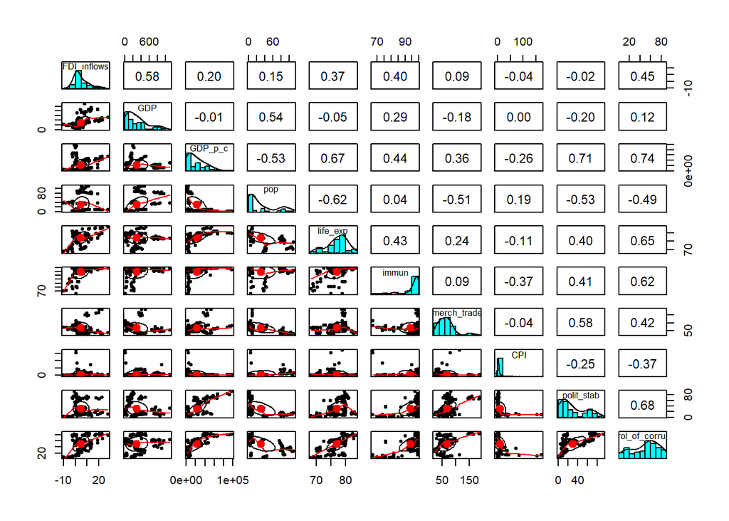

```r
data1<-data.frame(data[,-c(1,2)])
pairs.panels(data1)
```

### 1.4 Изучение панельных данных

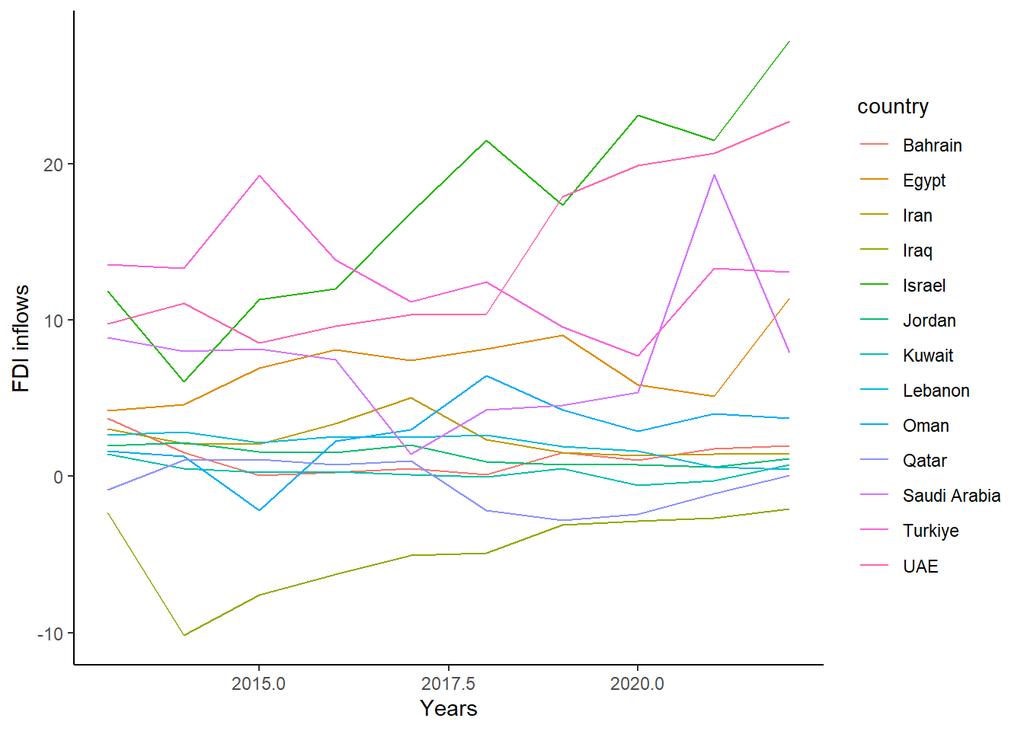

```r
h1 <- data.frame(data);
ggplot(data=h1,aes(x=years,y= FDI_inflows,color = country)) +
  geom_line() +
  labs(x="Years",y="FDI inflows",color= "country")+theme_classic()
```

**Фиксированные эффекты: неоднородность по годам**

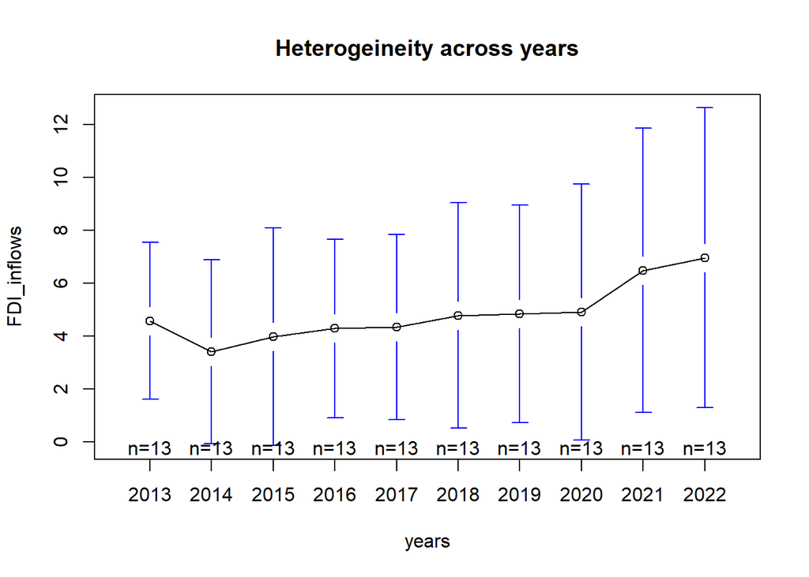

```r
plotmeans(FDI_inflows ~ years, main="Heterogeineity across years", data=data)
```

```r
# plotmeans draw a 95% confidence interval around the means
```

По графику можно сделать вывод, что объём чистых прямых иностранных инвестиций постепенно растёт с течением лет, так как показатель в 2022 годы намного выше показателя в 2013 году для стран Ближнего Востока.

### 1.5 Корреляционная матрица

```r
cor_mat <- data.frame(h$FDI_inflows,h$GDP,h$GDP_p_c, h$pop, h$life_exp, h$immun, h$merch_trade, h$CPI, h$polit_stab, h$control_of_corruption)
corr_matrix <- round(cor(cor_mat),2);corr_matrix
```

```
##                         h.FDI_inflows h.GDP h.GDP_p_c h.pop h.life_exp h.immun
## h.FDI_inflows                    1.00  0.58      0.20  0.15       0.37    0.40
## h.GDP                            0.58  1.00     -0.01  0.54      -0.05    0.29
## h.GDP_p_c                        0.20 -0.01      1.00 -0.53       0.67    0.44
## h.pop                            0.15  0.54     -0.53  1.00      -0.62    0.04
## h.life_exp                       0.37 -0.05      0.67 -0.62       1.00    0.43
## h.immun                          0.40  0.29      0.44  0.04       0.43    1.00
## h.merch_trade                    0.09 -0.18      0.36 -0.51       0.24    0.09
## h.CPI                           -0.04  0.00     -0.26  0.19      -0.11   -0.37
## h.polit_stab                    -0.02 -0.20      0.71 -0.53       0.40    0.41
## h.control_of_corruption          0.45  0.12      0.74 -0.49       0.65    0.62
##                         h.merch_trade h.CPI h.polit_stab
## h.FDI_inflows                    0.09 -0.04        -0.02
## h.GDP                           -0.18  0.00        -0.20
## h.GDP_p_c                        0.36 -0.26         0.71
## h.pop                           -0.51  0.19        -0.53
## h.life_exp                       0.24 -0.11         0.40
## h.immun                          0.09 -0.37         0.41
## h.merch_trade                    1.00 -0.04         0.58
## h.CPI                           -0.04  1.00        -0.25
## h.polit_stab                     0.58 -0.25         1.00
## h.control_of_corruption          0.42 -0.37         0.68
##                         h.control_of_corruption
## h.FDI_inflows                              0.45
## h.GDP                                      0.12
## h.GDP_p_c                                  0.74
## h.pop                                     -0.49
## h.life_exp                                 0.65
## h.immun                                    0.62
## h.merch_trade                              0.42
## h.CPI                                     -0.37
## h.polit_stab                               0.68
## h.control_of_corruption                    1.00
```

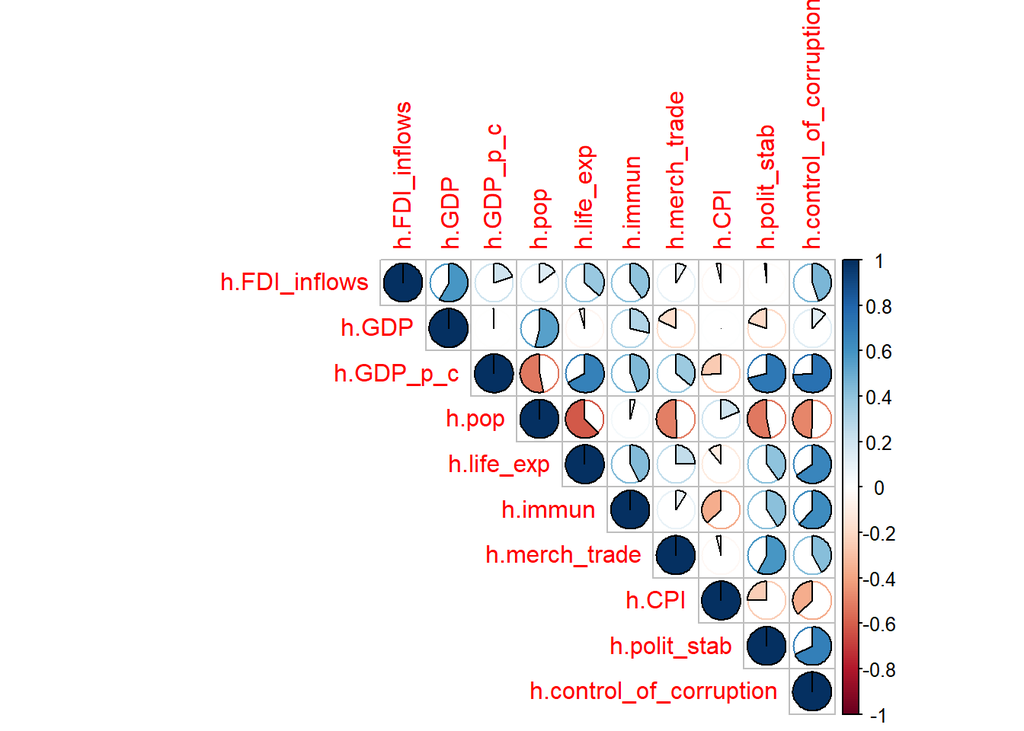

```r
corrplot(corr_matrix, method="pie",type="upper",order="original")
```

**Выводы:**

1. Наблюдается средняя линейная положительная зависимость между притоками прямых иностранных инвестиций и ВВП, **r = 0,58**;
2. Наблюдается средняя линейная положительная зависимость между притоками прямых иностранных инвестиций и ожидаемой продолжительностью жизни при рождении, **r = 0,37**;
3. Наблюдается средняя линейная положительная зависимость между притоками прямых иностранных инвестиций и уровнем иммунизации, **r = 0,4**;
4. Наблюдается средняя линейная положительная зависимость между притоками прямых иностранных инвестиций и уровнем контроля коррупции, **r = 0,45**;
5. Наблюдается средняя линейная положительная зависимость между ВВП и численностью населения, **r = 0,54**;
6. Наблюдается средняя линейная положительная зависимость между ВВП на душу населения и ожидаемой продолжительностью жизни, **r = 0,67**;
7. Наблюдается сильная линейная положительная зависимость между ВВП на душу населения и уровнем политической стабильности, **r = 0,71**;
8. Наблюдается сильная линейная положительная зависимость между ВВП на душу населения и уровнем контроля коррупции, **r = 0,74**;
9. Наблюдается средняя линейная отрицательная зависимость между численностью населения и ожидаемой продолжительностью жизни, **r = -0,62**;
10. Наблюдается средняя линейная положительная зависимость между уровнем контроля коррупции и ожидаемой продолжительностью жизни, **r = 0,65**;
11. Наблюдается средняя линейная положительная зависимость между уровнем контроля коррупции и уровнем иммунизации, **r = 0,62**;
12. Наблюдается средняя линейная положительная зависимость между уровнем контроля коррупции и уровнем политической стабильности, **r = 0,68**.

```r
round(cor(data1, method= "spearman"),2)
```

```
##                       FDI_inflows   GDP GDP_p_c   pop life_exp immun
## FDI_inflows                  1.00  0.62    0.12  0.37     0.15  0.20
## GDP                          0.62  1.00    0.12  0.65    -0.12  0.10
## GDP_p_c                      0.12  0.12    1.00 -0.65     0.82  0.54
## pop                          0.37  0.65   -0.65  1.00    -0.70 -0.36
## life_exp                     0.15 -0.12    0.82 -0.70     1.00  0.47
## immun                        0.20  0.10    0.54 -0.36     0.47  1.00
## merch_trade                 -0.27 -0.44    0.39 -0.62     0.24  0.22
## CPI                          0.16  0.27   -0.42  0.47    -0.35 -0.13
## polit_stab                   0.00 -0.10    0.64 -0.55     0.44  0.53
## control_of_corruption        0.37  0.13    0.74 -0.43     0.60  0.55
##                       merch_trade   CPI polit_stab control_of_corruption
## FDI_inflows                 -0.27  0.16       0.00                  0.37
## GDP                         -0.44  0.27      -0.10                  0.13
## GDP_p_c                      0.39 -0.42       0.64                  0.74
## pop                         -0.62  0.47      -0.55                 -0.43
## life_exp                     0.24 -0.35       0.44                  0.60
## immun                        0.22 -0.13       0.53                  0.55
## merch_trade                  1.00 -0.31       0.53                  0.34
## CPI                         -0.31  1.00      -0.36                 -0.43
## polit_stab                   0.53 -0.36       1.00                  0.76
## control_of_corruption        0.34 -0.43       0.76                  1.00
```

**Выводы:**

1. Наблюдается средняя линейная положительная зависимость между притоками прямых иностранных инвестиций и ВВП, **r = 0,62**;
2. Наблюдается средняя линейная положительная зависимость между ВВП и численностью населения, **r = 0,65**;
3. Наблюдается сильная линейная положительная зависимость между ВВП на душу населения и ожидаемой продолжительностью жизни, **r = 0,82**;
4. Наблюдается средняя линейная положительная зависимость между ВВП на душу населения и уровнем политической стабильности, **r = 0,64**;
5. Наблюдается сильная линейная положительная зависимость между ВВП на душу населения и уровнем контроля коррупции, **r = 0,74**;
6. Наблюдается сильная линейная отрицательная зависимость между численностью населения и ожидаемой продолжительностью жизни, **r = -0,70**;
7. Наблюдается средняя линейная положительная зависимость между уровнем контроля коррупции и ожидаемой продолжительностью жизни, **r = 0,6**;
8. Наблюдается средняя линейная положительная зависимость между уровнем контроля коррупции и уровнем иммунизации, **r = 0,55**;
9. Наблюдается сильная линейная положительная зависимость между уровнем контроля коррупции и уровнем политической стабильности, **r = 0,76**.

```r
round(cor(data1, method= "kendall"),2)
```

```
##                       FDI_inflows   GDP GDP_p_c   pop life_exp immun
## FDI_inflows                  1.00  0.40    0.10  0.25     0.10  0.15
## GDP                          0.40  1.00    0.13  0.42    -0.05  0.07
## GDP_p_c                      0.10  0.13    1.00 -0.45     0.60  0.41
## pop                          0.25  0.42   -0.45  1.00    -0.46 -0.25
## life_exp                     0.10 -0.05    0.60 -0.46     1.00  0.35
## immun                        0.15  0.07    0.41 -0.25     0.35  1.00
## merch_trade                 -0.17 -0.30    0.28 -0.44     0.15  0.14
## CPI                          0.11  0.18   -0.28  0.31    -0.24 -0.10
## polit_stab                  -0.01 -0.02    0.46 -0.37     0.31  0.40
## control_of_corruption        0.27  0.09    0.53 -0.29     0.43  0.42
##                       merch_trade   CPI polit_stab control_of_corruption
## FDI_inflows                 -0.17  0.11      -0.01                  0.27
## GDP                         -0.30  0.18      -0.02                  0.09
## GDP_p_c                      0.28 -0.28       0.46                  0.53
## pop                         -0.44  0.31      -0.37                 -0.29
## life_exp                     0.15 -0.24       0.31                  0.43
## immun                        0.14 -0.10       0.40                  0.42
## merch_trade                  1.00 -0.20       0.35                  0.24
## CPI                         -0.20  1.00      -0.24                 -0.31
## polit_stab                   0.35 -0.24       1.00                  0.56
## control_of_corruption        0.24 -0.31       0.56                  1.00
```

**Выводы:**

1. Наблюдается средняя линейная положительная зависимость между притоками прямых иностранных инвестиций и ВВП, **r = 0,4**;
2. Наблюдается средняя линейная положительная зависимость между ВВП и численностью населения, **r = 0,42**;
3. Наблюдается средняя линейная положительная зависимость между ВВП на душу населения и ожидаемой продолжительностью жизни, **r = 0,6**;
4. Наблюдается средняя линейная положительная зависимость между ВВП на душу населения и уровнем политической стабильности, **r = 0,46**;
5. Наблюдается средняя линейная положительная зависимость между ВВП на душу населения и уровнем контроля коррупции, **r = 0,53**;
6. Наблюдается средняя линейная отрицательная зависимость между численностью населения и ожидаемой продолжительностью жизни, **r = -0,46**;
7. Наблюдается средняя линейная положительная зависимость между уровнем контроля коррупции и ожидаемой продолжительностью жизни, **r = 0,43**;
8. Наблюдается средняя линейная положительная зависимость между уровнем контроля коррупции и уровнем иммунизации, **r = 0,42**;
9. Наблюдается средняя линейная положительная зависимость между уровнем контроля коррупции и уровнем политической стабильности, **r = 0,56**.

### 1.6 Панельные модели

Модель сквозной регрессии

```r
m.pooled <- plm(FDI_inflows ~ GDP + GDP_p_c + pop + life_exp + immun + merch_trade + CPI + polit_stab + control_of_corruption, data = h, model = "pooling")
```

```r
options(scipen = 999)
summary(m.pooled)
```

```
## Pooling Model
##
## Call:
## plm(formula = FDI_inflows ~ GDP + GDP_p_c + pop + life_exp +
##     immun + merch_trade + CPI + polit_stab + control_of_corruption,
##     data = h, model = "pooling")
##
## Balanced Panel: n = 13, T = 10, N = 130
##
## Residuals:
##     Min.  1st Qu.   Median  3rd Qu.     Max.
## -8.69485 -2.26908 -0.64898  2.30001 13.86263
##
## Coefficients:
##                            Estimate    Std. Error t-value      Pr(>|t|)
## (Intercept)           -76.364845688  14.169106520 -5.3895 0.00000035841 ***
## GDP                     0.006163655   0.002088634  2.9510     0.0038096 **
## GDP_p_c                -0.000037970   0.000032765 -1.1588     0.2488185
## pop                     0.115218587   0.026542834  4.3409 0.00002980251 ***
## life_exp                1.042544100   0.214444009  4.8616 0.00000356436 ***
## immun                  -0.146856483   0.081272435 -1.8070     0.0732733 .
## merch_trade             0.056072839   0.014633859  3.8317     0.0002040 ***
## CPI                    -0.006096436   0.019265239 -0.3164     0.7522127
## polit_stab             -0.094876999   0.027363072 -3.4673     0.0007304 ***
## control_of_corruption   0.190114155   0.032099424  5.9227 0.00000003095 ***
## ---
## Signif. codes:  0 '***' 0.001 '**' 0.01 '*' 0.05 '.' 0.1 ' ' 1
##
## Total Sum of Squares:    6075.7
## Residual Sum of Squares: 2051.2
## R-Squared:      0.6624
## Adj. R-Squared: 0.63708
## F-statistic: 26.1612 on 9 and 120 DF, p-value: < 0.000000000000000222
```

> Все переменные кроме ВВП на душу населения, уровня иммунизации и инфляции по ИПЦ проходят t-test на значимость коэффициентов, так как $p_{value} < 0.05$ .

> Модель проходит F-test на значимость коэффициента детерминации, так как $p_{value} = 2.22*10^{-16} < 0.05$

> Коэффициент детерминации $R^2$ равен 0.6624.

> Коэффициент исправленной детерминации $adjR^2$ равен 0.63708.

Модель со случайными эффектами

```r
m.re <- plm(FDI_inflows ~ GDP + GDP_p_c + pop + life_exp + immun + merch_trade + CPI + polit_stab + control_of_corruption, data = h, model = "random")
```

```r
options(scipen = 999)
summary(m.re)
```

```
## Oneway (individual) effect Random Effect Model
##    (Swamy-Arora's transformation)
##
## Call:
## plm(formula = FDI_inflows ~ GDP + GDP_p_c + pop + life_exp +
##     immun + merch_trade + CPI + polit_stab + control_of_corruption,
##     data = h, model = "random")
##
## Balanced Panel: n = 13, T = 10, N = 130
##
## Effects:
##                  var std.dev share
## idiosyncratic  8.250   2.872 0.279
## individual    21.341   4.620 0.721
## theta: 0.8071
##
## Residuals:
##      Min.   1st Qu.    Median   3rd Qu.      Max.
## -8.469061 -1.436080 -0.086515  1.397602  9.226195
##
## Coefficients:
##                            Estimate    Std. Error z-value   Pr(>|z|)
## (Intercept)           -39.998551727  19.133062511 -2.0905    0.03657 *
## GDP                     0.016611982   0.004193363  3.9615 0.00007448 ***
## GDP_p_c                 0.000064095   0.000052664  1.2170    0.22359
## pop                     0.008340636   0.050916476  0.1638    0.86988
## life_exp                0.394411389   0.256761034  1.5361    0.12451
## immun                   0.070341272   0.081446176  0.8637    0.38778
## merch_trade             0.045223430   0.026679552  1.6951    0.09006 .
## CPI                    -0.005644658   0.016689619 -0.3382    0.73520
## polit_stab             -0.081121089   0.049868611 -1.6267    0.10380
## control_of_corruption   0.013605212   0.053992846  0.2520    0.80106
## ---
## Signif. codes:  0 '***' 0.001 '**' 0.01 '*' 0.05 '.' 0.1 ' ' 1
##
## Total Sum of Squares:    1352
## Residual Sum of Squares: 980.79
## R-Squared:      0.27457
## Adj. R-Squared: 0.22017
## Chisq: 45.4198 on 9 DF, p-value: 0.0000007715
```

> Все переменные кроме ВВП не проходят t-test на значимость коэффициентов, так как $p_{value} > 0.05$ .

> Модель проходит F-test на значимость коэффициента детерминации, так как $p_{value} = 0.0000007715 < 0.05$

> Коэффициент детерминации $R^2$ равен 0.27457.

> Коэффициент исправленной детерминации $adjR^2$ равен 0.22017.

Модель с фиксированными эффектами

```r
m.fe <- plm(FDI_inflows ~ GDP + GDP_p_c + pop + life_exp + immun + merch_trade + CPI + polit_stab + control_of_corruption, data = h, model = "within")
```

```r
options(scipen = 999)
summary(m.fe)
```

```
## Oneway (individual) effect Within Model
##
## Call:
## plm(formula = FDI_inflows ~ GDP + GDP_p_c + pop + life_exp +
##     immun + merch_trade + CPI + polit_stab + control_of_corruption,
##     data = h, model = "within")
##
## Balanced Panel: n = 13, T = 10, N = 130
##
## Residuals:
##      Min.   1st Qu.    Median   3rd Qu.      Max.
## -9.559187 -1.380315  0.027451  1.113787 10.030668
##
## Coefficients:
##                           Estimate   Std. Error t-value  Pr(>|t|)
## GDP                    0.020445798  0.005274898  3.8761 0.0001826 ***
## GDP_p_c                0.000064768  0.000062985  1.0283 0.3060981
## pop                    0.048419852  0.139873087  0.3462 0.7298885
## life_exp               0.209634886  0.316090098  0.6632 0.5086076
## immun                  0.071090940  0.086688996  0.8201 0.4139831
## merch_trade            0.045936638  0.032949400  1.3942 0.1661318
## CPI                   -0.010165990  0.018466934 -0.5505 0.5831155
## polit_stab            -0.089364051  0.067276899 -1.3283 0.1868784
## control_of_corruption -0.038979311  0.073506615 -0.5303 0.5970043
## ---
## Signif. codes:  0 '***' 0.001 '**' 0.01 '*' 0.05 '.' 0.1 ' ' 1
##
## Total Sum of Squares:    1169.4
## Residual Sum of Squares: 891.04
## R-Squared:      0.23804
## Adj. R-Squared: 0.089878
## F-statistic: 3.74881 on 9 and 108 DF, p-value: 0.00039265
```

> Все переменные кроме ВВП не проходят t-test на значимость коэффициентов, так как $p_{value} > 0.05$ .

> Модель проходит F-test на значимость коэффициента детерминации, так как $p_{value} = 0.00039265 < 0.05$

> Коэффициент детерминации $R^2$ равен 0.23804

> Коэффициент исправленной детерминации $adjR^2$ равен 0.089878

**Проведём три теста на сравнение моделей.**

Фиксированные эффекты против сквозной регрессии. F-тест (тест Вальда).

```r
pFtest(m.fe, m.pooled)
```

```
##
##  F test for individual effects
##
## data:  FDI_inflows ~ GDP + GDP_p_c + pop + life_exp + immun + merch_trade +  ...
## F = 11.718, df1 = 12, df2 = 108, p-value = 0.000000000000008697
## alternative hypothesis: significant effects
```

Результаты теста Вальда проверяем значимость фиксированных эффектов

$p-value = 0.000000000000008697 < \alpha = 0.05$ - фиксированные эффекты значимы.

Предпочтение отдаётся модели с фиксированными эффектами (FE), нежели модели сквозной регрессии (pooling).

Случайные эффекты против сквозной регрессии. Тест Бройша-Пагана, является одним из тестов множителей Лагранжа.

```r
plmtest(m.re, type = "bp")
```

```
##
##  Lagrange Multiplier Test - (Breusch-Pagan)
##
## data:  FDI_inflows ~ GDP + GDP_p_c + pop + life_exp + immun + merch_trade +  ...
## chisq = 75.537, df = 1, p-value < 0.00000000000000022
## alternative hypothesis: significant effects
```

Результаты теста Бройша-Пагана проверяем значимость случайных эффектов

$p-value = 0.00000000000000022 < \alpha = 0.05$ - случайных эффекты значимы.

Предпочтение отдаётся модели со случайными эффектами (RE), нежели модели сквозной регрессии (pooling).

#### 1.6.1 Сравниваем модели с FE и RE эффектами

Фиксированные эффекты против случайных эффектов. Тест Хаусмана.

```r
phtest(m.fe, m.re)
```

```
##
##  Hausman Test
##
## data:  FDI_inflows ~ GDP + GDP_p_c + pop + life_exp + immun + merch_trade +  ...
## chisq = 7.0422, df = 9, p-value = 0.6327
## alternative hypothesis: one model is inconsistent
```

Результаты теста Хаусмана проверяем значимость случайных эффектов

$p-value = 0.6327 > \alpha = 0.05$ - случайных эффекты значимы.

**Предпочтение отдаётся модели со случайными эффектами (RE) нежели модели с фиксированными эффектами (FE).**

```r
fixed <- plm(FDI_inflows ~ GDP + GDP_p_c + pop + life_exp + immun + merch_trade + CPI + polit_stab + control_of_corruption, data=data, index=c("country", "years"),
model="within")
```

**Тестирование эффектов, фиксированных по времени**

```r
fixed <- plm(FDI_inflows ~ GDP + GDP_p_c + pop + life_exp + immun + merch_trade + CPI + polit_stab + control_of_corruption, data=data, index=c("country", "years"),
model="within")
fixed.time <- plm(FDI_inflows ~ GDP + GDP_p_c + pop + life_exp + immun + merch_trade + CPI + polit_stab + control_of_corruption + factor(years), data=data, index=c("country", "years"),
model="within")
summary(fixed.time)
```

```
## Oneway (individual) effect Within Model
##
## Call:
## plm(formula = FDI_inflows ~ GDP + GDP_p_c + pop + life_exp +
##     immun + merch_trade + CPI + polit_stab + control_of_corruption +
##     factor(years), data = data, model = "within", index = c("country",
##     "years"))
##
## Balanced Panel: n = 13, T = 10, N = 130
##
## Residuals:
##     Min.  1st Qu.   Median  3rd Qu.     Max.
## -6.71745 -1.49643 -0.16897  1.17030  7.56115
##
## Coefficients:
##                          Estimate  Std. Error t-value   Pr(>|t|)
## GDP                    0.02091707  0.00567859  3.6835  0.0003751 ***
## GDP_p_c                0.00012052  0.00005898  2.0433  0.0436762 *
## pop                   -0.47286711  0.16342621 -2.8935  0.0046864 **
## life_exp               1.13170375  0.39490875  2.8657  0.0050819 **
## immun                  0.12459434  0.08193101  1.5207  0.1315170
## merch_trade            0.09806960  0.03793076  2.5855  0.0111809 *
## CPI                   -0.01802487  0.01769972 -1.0184  0.3109841
## polit_stab            -0.10025084  0.06185358 -1.6208  0.1082465
## control_of_corruption -0.01943483  0.06902191 -0.2816  0.7788573
## factor(years)2014     -0.66028826  1.04068932 -0.6345  0.5272363
## factor(years)2015      1.52099994  1.14279461  1.3309  0.1862633
## factor(years)2016      2.40243589  1.24960964  1.9225  0.0574110 .
## factor(years)2017      1.77399722  1.24204984  1.4283  0.1563580
## factor(years)2018      1.54877596  1.23530564  1.2538  0.2128821
## factor(years)2019      2.25573575  1.26684333  1.7806  0.0780460 .
## factor(years)2020      5.65780960  1.40945675  4.0142  0.0001161 ***
## factor(years)2021      5.55919056  1.33339512  4.1692 0.00006557 ***
## factor(years)2022      1.96838935  1.35422132  1.4535  0.1492418
## ---
## Signif. codes:  0 '***' 0.001 '**' 0.01 '*' 0.05 '.' 0.1 ' ' 1
##
## Total Sum of Squares:    1169.4
## Residual Sum of Squares: 675.69
## R-Squared:      0.42219
## Adj. R-Squared: 0.2471
## F-statistic: 4.01869 on 18 and 99 DF, p-value: 0.0000036711
```

```r
pFtest(fixed.time, fixed)  # тест Вальда
```

```
##
##  F test for individual effects
##
## data:  FDI_inflows ~ GDP + GDP_p_c + pop + life_exp + immun + merch_trade +  ...
## F = 3.5058, df1 = 9, df2 = 99, p-value = 0.0008413
## alternative hypothesis: significant effects
```

```r
plmtest(fixed, c("time"), type=("bp")) # тест BP
```

```
##
##  Lagrange Multiplier Test - time effects (Breusch-Pagan)
##
## data:  FDI_inflows ~ GDP + GDP_p_c + pop + life_exp + immun + merch_trade +  ...
## chisq = 0.0044631, df = 1, p-value = 0.9467
## alternative hypothesis: significant effects
```

#### 1.6.2 Проведём тест на кросскорреляцию

```r
pcdtest(m.re, test = c("lm")) # Breusch-Pagan LM test
```

```
##
##  Breusch-Pagan LM test for cross-sectional dependence in panels
##
## data:  FDI_inflows ~ GDP + GDP_p_c + pop + life_exp + immun + merch_trade +     CPI + polit_stab + control_of_corruption
## chisq = 127.34, df = 78, p-value = 0.0003573
## alternative hypothesis: cross-sectional dependence
```

```r
pcdtest(m.re, test = c("cd")) # Pesaran CD
```

```
##
##  Pesaran CD test for cross-sectional dependence in panels
##
## data:  FDI_inflows ~ GDP + GDP_p_c + pop + life_exp + immun + merch_trade +     CPI + polit_stab + control_of_corruption
## z = 4.513, p-value = 0.000006393
## alternative hypothesis: cross-sectional dependence
```

**Вывод:** кросскорреляция имеется, поэтому следует построить модель с лагами.

```r
pcdtest(fixed, test = c("lm")) # Breusch-Pagan LM test
```

```
##
##  Breusch-Pagan LM test for cross-sectional dependence in panels
##
## data:  FDI_inflows ~ GDP + GDP_p_c + pop + life_exp + immun + merch_trade +     CPI + polit_stab + control_of_corruption
## chisq = 118.23, df = 78, p-value = 0.002243
## alternative hypothesis: cross-sectional dependence
```

```r
pcdtest(fixed, test = c("cd")) # Pesaran CD
```

```
##
##  Pesaran CD test for cross-sectional dependence in panels
##
## data:  FDI_inflows ~ GDP + GDP_p_c + pop + life_exp + immun + merch_trade +     CPI + polit_stab + control_of_corruption
## z = 3.0288, p-value = 0.002455
## alternative hypothesis: cross-sectional dependence
```

**Вывод:** кросскорреляция имеется, поэтому следует построить модель с лагами.

#### 1.6.3 Тестирование на последовательную корреляцию (Testing for serial correlation)

```r
pbgtest(fixed)
```

```
##
##  Breusch-Godfrey/Wooldridge test for serial correlation in panel models
##
## data:  FDI_inflows ~ GDP + GDP_p_c + pop + life_exp + immun + merch_trade +  ...
## chisq = 25.541, df = 10, p-value = 0.00441
## alternative hypothesis: serial correlation in idiosyncratic errors
```

**Вывод:** есть последовательная корреляция.

#### 1.6.4 Тестирование на единичные корни/стационарность

```r
Panel.set <- plm.data(data, index = c("country", "years"))
adf.test(Panel.set$FDI_inflows, k=10)
```

```
##
##  Augmented Dickey-Fuller Test
##
## data:  Panel.set$FDI_inflows
## Dickey-Fuller = -2.4353, Lag order = 10, p-value = 0.3955
## alternative hypothesis: stationary
```

**Вывод:** стационарности нет.

#### 1.6.5 Тестирование на гетероскедастичность.

```r
bptest(FDI_inflows ~ GDP + GDP_p_c + pop + life_exp + immun + merch_trade + CPI + polit_stab + control_of_corruption + factor(country),  data = data, studentize=F)
```

```
##
##  Breusch-Pagan test
##
## data:  FDI_inflows ~ GDP + GDP_p_c + pop + life_exp + immun + merch_trade +     CPI + polit_stab + control_of_corruption + factor(country)
## BP = 99.113, df = 21, p-value = 0.000000000004141
```

**Вывод:** есть гетероскедастичность.

## ARDL model

### 1.1 Порядок построение модели ARDL

**Преобразуем таблицу в панельные данные:**

```r
h <- pdata.frame(data, index = c("country", "years"), row.names = TRUE)
attach(h)
head(h)
```

```
##              country years FDI_inflows      GDP  GDP_p_c      pop life_exp
## Bahrain-2013 Bahrain  2013  3.72771277 32.53947 25790.73 1.261673   79.246
## Bahrain-2014 Bahrain  2014  1.51861702 33.38771 25464.76 1.311134   79.328
## Bahrain-2015 Bahrain  2015  0.06489362 31.05064 22795.45 1.362142   79.405
## Bahrain-2016 Bahrain  2016  0.24335106 32.23497 22867.18 1.409661   79.557
## Bahrain-2017 Bahrain  2017  0.51888298 35.47378 24349.91 1.456834   79.689
## Bahrain-2018 Bahrain  2018  0.11117021 37.80201 25415.85 1.487340   79.857
##              immun merch_trade      CPI polit_stab control_of_corruption
## Bahrain-2013    99    98.11777 3.300012    9.00474              68.24644
## Bahrain-2014    99    96.87995 2.647553   15.71429              62.98077
## Bahrain-2015    99    93.22836 1.848627   12.85714              59.04762
## Bahrain-2016    99    75.58250 2.786793   19.52381              55.71429
## Bahrain-2017    99    80.40024 1.386718   14.28571              50.47619
## Bahrain-2018    99    87.07210 2.087669   17.45283              50.00000
```

#### 1.1.1 Проверка стационарности данных.

Нулевая гипотеза по тестам:  
1. Phillips-Perron Unit Root Test - ряд нестационарен

2. Augmented Dickey-Fuller Test - ряд нестационарен
3. KPSS Test for Level Stationarity - ряд стационарен.

При $p_{value} > \alpha = 0.05$ верна нулевая гипотеза.

```r
pp.test(FDI_inflows)
```

```
##
##  Phillips-Perron Unit Root Test
##
## data:  FDI_inflows
## Dickey-Fuller Z(alpha) = -23.216, Truncation lag parameter = 4, p-value
## = 0.02959
## alternative hypothesis: stationary
```

```r
adf.test(FDI_inflows)
```

```
##
##  Augmented Dickey-Fuller Test
##
## data:  FDI_inflows
## Dickey-Fuller = -2.973, Lag order = 5, p-value = 0.172
## alternative hypothesis: stationary
```

```r
kpss.test(FDI_inflows)
```

```
##
##  KPSS Test for Level Stationarity
##
## data:  FDI_inflows
## KPSS Level = 0.47505, Truncation lag parameter = 4, p-value = 0.04729
```

Данные о притоке ПИИ по тестам Диккей-Фуллера и kpss являются нестационарными, а поо тесту Филлипса-Перрона стацинарными.  
Следовательно следует взять разницу первого порядка.

```r
dFDI_inflows<-diff(FDI_inflows)
adf.test(dFDI_inflows)
```

```
##
##  Augmented Dickey-Fuller Test
##
## data:  dFDI_inflows
## Dickey-Fuller = -4.7544, Lag order = 5, p-value = 0.01
## alternative hypothesis: stationary
```

**Данные о притоках ПИИ имеют уровень I(1).**

```r
pp.test(GDP)
```

```
##
##  Phillips-Perron Unit Root Test
##
## data:  GDP
## Dickey-Fuller Z(alpha) = -9.6801, Truncation lag parameter = 4, p-value
## = 0.5571
## alternative hypothesis: stationary
```

```r
adf.test(GDP)
```

```
##
##  Augmented Dickey-Fuller Test
##
## data:  GDP
## Dickey-Fuller = -2.214, Lag order = 5, p-value = 0.4875
## alternative hypothesis: stationary
```

Данные о ВВП нестационарны.

```r
dGDP<-diff(GDP)
adf.test(dGDP)
```

```
##
##  Augmented Dickey-Fuller Test
##
## data:  dGDP
## Dickey-Fuller = -4.3343, Lag order = 5, p-value = 0.01
## alternative hypothesis: stationary
```

**Данные о ВВП имеют уровень I(1).**

```r
pp.test(GDP_p_c)
```

```
##
##  Phillips-Perron Unit Root Test
##
## data:  GDP_p_c
## Dickey-Fuller Z(alpha) = -28.617, Truncation lag parameter = 4, p-value
## = 0.01
## alternative hypothesis: stationary
```

```r
adf.test(GDP_p_c)
```

```
##
##  Augmented Dickey-Fuller Test
##
## data:  GDP_p_c
## Dickey-Fuller = -3.4225, Lag order = 5, p-value = 0.05395
## alternative hypothesis: stationary
```

```r
kpss.test(GDP_p_c)
```

```
##
##  KPSS Test for Level Stationarity
##
## data:  GDP_p_c
## KPSS Level = 0.60787, Truncation lag parameter = 4, p-value = 0.02192
```

Данные о ВВП на душу населения нестационарны согласно KPSS test и тесту Диккей-Фуллера, но стационарны по тесту Филлипа-Перрона.

```r
dGDP_p_c<-diff(GDP_p_c)
adf.test(dGDP_p_c)
```

```
##
##  Augmented Dickey-Fuller Test
##
## data:  dGDP_p_c
## Dickey-Fuller = -5.124, Lag order = 5, p-value = 0.01
## alternative hypothesis: stationary
```

**Данные о ВВП на душу населения имеют уровень I(1).**

```r
pp.test(pop)
```

```
##
##  Phillips-Perron Unit Root Test
##
## data:  pop
## Dickey-Fuller Z(alpha) = -11.279, Truncation lag parameter = 4, p-value
## = 0.4648
## alternative hypothesis: stationary
```

```r
adf.test(pop)
```

```
##
##  Augmented Dickey-Fuller Test
##
## data:  pop
## Dickey-Fuller = -2.6258, Lag order = 5, p-value = 0.3163
## alternative hypothesis: stationary
```

Данные о численности населения нестационарны.

```r
dpop<-diff(pop)
adf.test(dpop)
```

```
##
##  Augmented Dickey-Fuller Test
##
## data:  dpop
## Dickey-Fuller = -4.4319, Lag order = 5, p-value = 0.01
## alternative hypothesis: stationary
```

**Данные о численности населения имеют уровень I(1).**

```r
pp.test(life_exp)
```

```
##
##  Phillips-Perron Unit Root Test
##
## data:  life_exp
## Dickey-Fuller Z(alpha) = -24.593, Truncation lag parameter = 4, p-value
## = 0.02172
## alternative hypothesis: stationary
```

```r
adf.test(life_exp)
```

```
##
##  Augmented Dickey-Fuller Test
##
## data:  life_exp
## Dickey-Fuller = -4.0566, Lag order = 5, p-value = 0.01
## alternative hypothesis: stationary
```

**Данные об ожидаемой продолжительности жизни стационарны I(0).**

```r
pp.test(immun)
```

```
##
##  Phillips-Perron Unit Root Test
##
## data:  immun
## Dickey-Fuller Z(alpha) = -28.793, Truncation lag parameter = 4, p-value
## = 0.01
## alternative hypothesis: stationary
```

```r
adf.test(immun)
```

```
##
##  Augmented Dickey-Fuller Test
##
## data:  immun
## Dickey-Fuller = -3.4838, Lag order = 5, p-value = 0.04659
## alternative hypothesis: stationary
```

**Данные об уровне иммунизации стационарны I(0).**

```r
pp.test(merch_trade)
```

```
##
##  Phillips-Perron Unit Root Test
##
## data:  merch_trade
## Dickey-Fuller Z(alpha) = -11.151, Truncation lag parameter = 4, p-value
## = 0.4722
## alternative hypothesis: stationary
```

```r
adf.test(merch_trade)
```

```
##
##  Augmented Dickey-Fuller Test
##
## data:  merch_trade
## Dickey-Fuller = -1.5919, Lag order = 5, p-value = 0.7462
## alternative hypothesis: stationary
```

Данные о доле торговли товарами от ВВП нестационарны.

```r
dmerch_trade<-diff(merch_trade)
adf.test(dmerch_trade)
```

```
##
##  Augmented Dickey-Fuller Test
##
## data:  dmerch_trade
## Dickey-Fuller = -5.0657, Lag order = 5, p-value = 0.01
## alternative hypothesis: stationary
```

**Данные о доле торговли товарами от ВВП имеют уровень I(1).**

```r
pp.test(CPI)
```

```
##
##  Phillips-Perron Unit Root Test
##
## data:  CPI
## Dickey-Fuller Z(alpha) = -48.141, Truncation lag parameter = 4, p-value
## = 0.01
## alternative hypothesis: stationary
```

```r
adf.test(CPI)
```

```
##
##  Augmented Dickey-Fuller Test
##
## data:  CPI
## Dickey-Fuller = -4.1748, Lag order = 5, p-value = 0.01
## alternative hypothesis: stationary
```

**Данные об уровне инфляции по ИПЦ стационарны I(0).**

```r
pp.test(polit_stab)
```

```
##
##  Phillips-Perron Unit Root Test
##
## data:  polit_stab
## Dickey-Fuller Z(alpha) = -18.007, Truncation lag parameter = 4, p-value
## = 0.09362
## alternative hypothesis: stationary
```

```r
adf.test(polit_stab)
```

```
##
##  Augmented Dickey-Fuller Test
##
## data:  polit_stab
## Dickey-Fuller = -2.811, Lag order = 5, p-value = 0.2393
## alternative hypothesis: stationary
```

Данные о политической стабильности нестационарны.

```r
dpolit_stab<-diff(polit_stab)
adf.test(dpolit_stab)
```

```
##
##  Augmented Dickey-Fuller Test
##
## data:  dpolit_stab
## Dickey-Fuller = -4.51, Lag order = 5, p-value = 0.01
## alternative hypothesis: stationary
```

**Данные о политической стабильности имеют уровень I(1).**

```r
pp.test(control_of_corruption)
```

```
##
##  Phillips-Perron Unit Root Test
##
## data:  control_of_corruption
## Dickey-Fuller Z(alpha) = -17.826, Truncation lag parameter = 4, p-value
## = 0.09644
## alternative hypothesis: stationary
```

```r
adf.test(control_of_corruption)
```

```
##
##  Augmented Dickey-Fuller Test
##
## data:  control_of_corruption
## Dickey-Fuller = -2.9288, Lag order = 5, p-value = 0.1904
## alternative hypothesis: stationary
```

Данные о контроле коррупции нестационарны.

```r
dcontrol_of_corruption<-diff(control_of_corruption)
adf.test(dcontrol_of_corruption)
```

```
##
##  Augmented Dickey-Fuller Test
##
## data:  dcontrol_of_corruption
## Dickey-Fuller = -4.4817, Lag order = 5, p-value = 0.01
## alternative hypothesis: stationary
```

**Данные о контроле коррупции имеют уровень I(1).**

#### 1.1.2 Вычисление оптимального лага для переменных.

Для этого используем библиотеку “vars”

```r
VARselect(FDI_inflows)
```

```
## $selection
## AIC(n)  HQ(n)  SC(n) FPE(n)
##      2      2      2      2
##
## $criteria
##                1         2         3         4         5         6         7
## AIC(n)  2.818087  2.784140  2.791706  2.807061  2.819952  2.822129  2.836706
## HQ(n)   2.836954  2.812440  2.829440  2.854228  2.876553  2.888163  2.912174
## SC(n)   2.864546  2.853827  2.884623  2.923207  2.959327  2.984733  3.022539
## FPE(n) 16.744846 16.186062 16.309224 16.561977 16.777446 16.814837 17.062863
##                8         9        10
## AIC(n)  2.852375  2.864244  2.877911
## HQ(n)   2.937276  2.958578  2.981679
## SC(n)   3.061437  3.096535  3.133431
## FPE(n) 17.333785 17.542582 17.786280
```

**Вывод:** Оптимальное количество лагов для притока ПИИ - 2.

```r
VARselect(GDP)
```

```
## $selection
## AIC(n)  HQ(n)  SC(n) FPE(n)
##      1      1      1      1
##
## $criteria
##                  1            2            3            4            5
## AIC(n)    9.208147     9.224248     9.219674     9.236015     9.252574
## HQ(n)     9.227014     9.252548     9.257408     9.283183     9.309174
## SC(n)     9.254606     9.293935     9.312590     9.352161     9.391948
## FPE(n) 9978.125390 10140.150820 10094.023332 10260.570126 10432.250150
##                   6            7            8            9           10
## AIC(n)     9.239866     9.256532     9.272764     9.284281     9.289898
## HQ(n)      9.305900     9.331999     9.357665     9.378615     9.393666
## SC(n)      9.402469     9.442364     9.481826     9.516572     9.545418
## FPE(n) 10301.021779 10474.821823 10647.139032 10771.597058 10833.669100
```

**Вывод:** Оптимальное количество лагов для ВВП - 1.

```r
VARselect(GDP_p_c)
```

```
## $selection
## AIC(n)  HQ(n)  SC(n) FPE(n)
##      1      1      1      1
##
## $criteria
##                      1               2               3               4
## AIC(n)        18.92092        18.93573        18.92841        18.94496
## HQ(n)         18.93979        18.96403        18.96614        18.99213
## SC(n)         18.96738        19.00541        19.02132        19.06111
## FPE(n) 164911850.36708 167373018.40231 166154727.87143 168932829.72407
##                      5               6               7               8
## AIC(n)        18.96003        18.97005        18.98626        19.00287
## HQ(n)         19.01663        19.03608        19.06173        19.08777
## SC(n)         19.09940        19.13265        19.17209        19.21193
## FPE(n) 171503435.94073 173238718.40867 176081262.56796 179045466.65392
##                      9              10
## AIC(n)        18.97517        18.93931
## HQ(n)         19.06950        19.04308
## SC(n)         19.20746        19.19483
## FPE(n) 174172708.72714 168058634.63733
```

**Вывод:** Оптимальное количество лагов для ВВП на душу населения - 1.

```r
VARselect(pop)
```

```
## $selection
## AIC(n)  HQ(n)  SC(n) FPE(n)
##      1      1      1      1
##
## $criteria
##                 1          2          3          4          5          6
## AIC(n)   5.206074   5.221180   5.236289   5.251252   5.266088   5.280792
## HQ(n)    5.224941   5.249481   5.274023   5.298420   5.322689   5.346826
## SC(n)    5.252532   5.290868   5.329206   5.367398   5.405463   5.443396
## FPE(n) 182.377161 185.154527 187.975943 190.814287 193.673052 196.551517
##                 7          8          9         10
## AIC(n)   5.295319   5.309892   5.324424   5.338705
## HQ(n)    5.370787   5.394793   5.418759   5.442473
## SC(n)    5.481152   5.518954   5.556715   5.594225
## FPE(n) 199.440746 202.385491 205.369722 208.350439
```

**Вывод:** Оптимальное количество лагов для численности населения - 1.

```r
VARselect(life_exp)
```

```
## $selection
## AIC(n)  HQ(n)  SC(n) FPE(n)
##      1      1      1      1
##
## $criteria
##               1        2        3        4        5        6        7        8
## AIC(n) 1.316630 1.331087 1.346179 1.359363 1.371903 1.380368 1.385771 1.384743
## HQ(n)  1.335497 1.359387 1.383913 1.406530 1.428504 1.446402 1.461239 1.469644
## SC(n)  1.363088 1.400774 1.439095 1.475508 1.511278 1.542972 1.571604 1.593804
## FPE(n) 3.730838 3.785195 3.842808 3.893899 3.943176 3.976893 3.998699 3.994925
##               9       10
## AIC(n) 1.392655 1.409280
## HQ(n)  1.486990 1.513048
## SC(n)  1.624946 1.664800
## FPE(n) 4.027084 4.095120
```

**Вывод:** Оптимальное количество лагов ожидаемой продолжительности жизни при рождении - 1.

```r
VARselect(immun)
```

```
## $selection
## AIC(n)  HQ(n)  SC(n) FPE(n)
##      2      1      1      2
##
## $criteria
##                1         2         3         4         5         6         7
## AIC(n)  3.318309  3.318256  3.334407  3.344706  3.360008  3.373107  3.385440
## HQ(n)   3.337176  3.346556  3.372140  3.391873  3.416609  3.439141  3.460907
## SC(n)   3.364767  3.387943  3.427323  3.460851  3.499383  3.535711  3.571272
## FPE(n) 27.613701 27.612436 28.062423 28.353595 28.791835 29.172884 29.536823
##                8         9        10
## AIC(n)  3.362462  3.368198  3.377403
## HQ(n)   3.447363  3.462533  3.481171
## SC(n)   3.571524  3.600489  3.632923
## FPE(n) 28.868311 29.037436 29.309728
```

**Вывод:** Оптимальное количество лагов для уровня иммунизации - 1, так как при малой выборке (13 стран и 10 лет) рекомендуется исходить из критериев HQ(n) и SC(n).

```r
VARselect(merch_trade)
```

```
## $selection
## AIC(n)  HQ(n)  SC(n) FPE(n)
##      1      1      1      1
##
## $criteria
##                 1          2          3          4          5          6
## AIC(n)   5.416267   5.430430   5.444840   5.461358   5.475403   5.491810
## HQ(n)    5.435134   5.458730   5.482574   5.508525   5.532003   5.557845
## SC(n)    5.462726   5.500117   5.537757   5.577503   5.614777   5.654414
## FPE(n) 225.038276 228.249785 231.565987 235.428240 238.766491 242.728392
##                 7          8          9         10
## AIC(n)   5.504922   5.518092   5.529698   5.515016
## HQ(n)    5.580390   5.602993   5.624032   5.618784
## SC(n)    5.690755   5.727154   5.761989   5.770536
## FPE(n) 245.948038 249.229553 252.165458 248.522198
```

**Вывод:** Оптимальное количество лагов доли торговли товарами от ВВП - 1.

```r
VARselect(CPI)
```

```
## $selection
## AIC(n)  HQ(n)  SC(n) FPE(n)
##      2      2      2      2
##
## $criteria
##                 1          2          3          4          5          6
## AIC(n)   5.911610   5.866032   5.881891   5.893675   5.901515   5.918088
## HQ(n)    5.930477   5.894333   5.919624   5.940842   5.958116   5.984122
## SC(n)    5.958068   5.935720   5.974807   6.009821   6.040890   6.080691
## FPE(n) 369.301398 352.849881 358.495251 362.753451 365.621611 371.749493
##                 7          8          9         10
## AIC(n)   5.933931   5.950523   5.966812   5.981451
## HQ(n)    6.009399   6.035424   6.061146   6.085219
## SC(n)    6.119764   6.159585   6.199103   6.236971
## FPE(n) 377.710946 384.062528 390.410724 396.218989
```

**Вывод:** Оптимальное количество лагов инфляции по потребительским ценам- 2.

```r
VARselect(polit_stab)
```

```
## $selection
## AIC(n)  HQ(n)  SC(n) FPE(n)
##      1      1      1      1
##
## $criteria
##                 1          2          3          4          5          6
## AIC(n)   4.848431   4.864946   4.880157   4.896393   4.912923   4.929584
## HQ(n)    4.867298   4.893247   4.917891   4.943560   4.969524   4.995618
## SC(n)    4.894889   4.934634   4.973073   5.012538   5.052298   5.092188
## FPE(n) 127.540538 129.665320 131.654552 133.812703 136.047887 138.340297
##                 7          8          9         10
## AIC(n)   4.934705   4.950958   4.961483   4.958687
## HQ(n)    5.010172   5.035859   5.055818   5.062455
## SC(n)    5.120537   5.160020   5.193774   5.214207
## FPE(n) 139.059596 141.350217 142.860771 142.480205
```

**Вывод:** Оптимальное количество лагов уровня политической стабильности - 1.

```r
VARselect(control_of_corruption)
```

```
## $selection
## AIC(n)  HQ(n)  SC(n) FPE(n)
##      1      1      1      1
##
## $criteria
##                 1          2          3          4          5          6
## AIC(n)   4.785200   4.801320   4.817607   4.823270   4.839218   4.853864
## HQ(n)    4.804067   4.829620   4.855341   4.870437   4.895818   4.919898
## SC(n)    4.831658   4.871007   4.910523   4.939416   4.978592   5.016468
## FPE(n) 119.725636 121.672195 123.671857 124.377133 126.380989 128.251948
##                 7          8          9         10
## AIC(n)   4.859724   4.876273   4.874643   4.891148
## HQ(n)    4.935192   4.961174   4.968977   4.994916
## SC(n)    5.045557   5.085335   5.106934   5.146668
## FPE(n) 129.014203 131.178052 130.978102 133.175013
```

**Вывод:** Оптимальное количество лагов уровня контроля коррупции - 1.

**Находим оптимальное количество лагов для всех независимых переменных**

```r
VARselect(data.frame(GDP,GDP_p_c, pop, life_exp, immun, merch_trade,CPI, polit_stab, control_of_corruption))
```

```
## $selection
## AIC(n)  HQ(n)  SC(n) FPE(n)
##     10      1      1      1
##
## $criteria
##                                     1                              2
## AIC(n)                       54.44233                       54.91872
## HQ(n)                        55.29134                       56.53184
## SC(n)                        56.53295                       58.89090
## FPE(n) 442099309206431772724668.00000 726776256840849783006802.00000
##                                      3                               4
## AIC(n)                        55.57636                        56.41651
## HQ(n)                         57.95359                        59.55785
## SC(n)                         61.43010                        64.15180
## FPE(n) 1481618564327076920320044.00000 3823311613005893212466026.00000
##                                      5                                6
## AIC(n)                        57.05987                         57.71740
## HQ(n)                         60.96532                         62.38696
## SC(n)                         66.67672                         69.21580
## FPE(n) 8750710173994774115208200.00000 22622541276151779260866682.00000
##                                       7                                 8
## AIC(n)                         58.27133                          58.24065
## HQ(n)                          63.70499                          64.43843
## SC(n)                          71.65129                          73.50217
## FPE(n) 61285381390955959404826860.00000 114605495295197751626048620.00000
##                                        9                              10
## AIC(n)                          57.50212                        51.79269
## HQ(n)                           64.46400                        59.51868
## SC(n)                           74.64520                        70.81732
## FPE(n) 144924516582791123944424860.00000 2099523711311593326248406.00000
```

**Вывод:** Оптимальное количество лагов для независимых переменных - 1.

### 1.2 Строим ARDL модель

Построим модель учитывающую оптимальное количество лагов для переменных.

```r
model1<-ardlDlm(formula = FDI_inflows ~  GDP + GDP_p_c +pop + life_exp + immun + merch_trade + CPI + polit_stab +control_of_corruption, data = h, p = 1, q = 2)
summary(model1)
```

```
##
## Time series regression with "ts" data:
## Start = 3, End = 130
##
## Call:
## dynlm(formula = as.formula(model.text), data = data)
##
## Residuals:
##     Min      1Q  Median      3Q     Max
## -8.1574 -1.2965 -0.0164  1.2599 11.5054
##
## Coefficients:
##                              Estimate    Std. Error t value      Pr(>|t|)
## (Intercept)             -34.490276144  12.989875883  -2.655       0.00914 **
## GDP.t                     0.010731506   0.004028319   2.664       0.00892 **
## GDP.1                    -0.009997726   0.004093677  -2.442       0.01623 *
## GDP_p_c.t                 0.000009921   0.000040040   0.248       0.80479
## GDP_p_c.1                -0.000032636   0.000040736  -0.801       0.42482
## pop.t                     0.038147985   0.040264590   0.947       0.34555
## pop.1                     0.018962737   0.039502249   0.480       0.63218
## life_exp.t                0.683437834   0.226080904   3.023       0.00313 **
## life_exp.1               -0.159332830   0.247802932  -0.643       0.52161
## immun.t                  -0.064692738   0.084229370  -0.768       0.44415
## immun.1                  -0.043672002   0.083236431  -0.525       0.60090
## merch_trade.t             0.010581302   0.030238127   0.350       0.72708
## merch_trade.1             0.015116280   0.030339361   0.498       0.61934
## CPI.t                    -0.019917752   0.019147182  -1.040       0.30057
## CPI.1                     0.011257898   0.020705082   0.544       0.58776
## polit_stab.t             -0.173322445   0.058584705  -2.958       0.00381 **
## polit_stab.1              0.143032871   0.058144193   2.460       0.01550 *
## control_of_corruption.t   0.147981805   0.050715584   2.918       0.00430 **
## control_of_corruption.1  -0.075657735   0.050901868  -1.486       0.14013
## FDI_inflows.1             0.552404316   0.088680648   6.229 0.00000000942 ***
## FDI_inflows.2             0.191206504   0.077352179   2.472       0.01502 *
## ---
## Signif. codes:  0 '***' 0.001 '**' 0.01 '*' 0.05 '.' 0.1 ' ' 1
##
## Residual standard error: 3.085 on 107 degrees of freedom
## Multiple R-squared:  0.832,  Adjusted R-squared:  0.8006
## F-statistic:  26.5 on 20 and 107 DF,  p-value: < 0.00000000000000022
```

Лаги первого порядка переменных ВВП на душу населения, численность населения , ожидаемая продолжительность жизни, уровень иммунизации, доля торговли товарами в ВВП и инфляция по ИПЦ не проходят t-test на значимость коэффициентов, поэтому мы их удаляем из модели.

```r
remove<-list(p=list(GDP_p_c=c(1), pop =c(1), life_exp=c(1), immun=c(1), merch_trade=c(1), CPI = c(1)))
```

Строим вторую модель.

```r
model2<-ardlDlm(formula = FDI_inflows ~  GDP + GDP_p_c +pop + life_exp + immun + merch_trade + CPI + polit_stab +control_of_corruption, data = h, p = 1, q = 2, remove = remove)
summary(model2)
```

```
##
## Time series regression with "ts" data:
## Start = 3, End = 130
##
## Call:
## dynlm(formula = as.formula(model.text), data = data)
##
## Residuals:
##     Min      1Q  Median      3Q     Max
## -8.1228 -1.2554 -0.1218  1.3549 11.5036
##
## Coefficients:
##                             Estimate   Std. Error t value      Pr(>|t|)
## (Intercept)             -41.30781886  11.09362800  -3.724      0.000308 ***
## GDP.t                     0.01262429   0.00333684   3.783      0.000249 ***
## GDP.1                    -0.01194651   0.00325617  -3.669      0.000373 ***
## GDP_p_c.t                -0.00001704   0.00002462  -0.692      0.490322
## pop.t                     0.06470159   0.02054967   3.149      0.002099 **
## life_exp.t                0.61700031   0.16544406   3.729      0.000302 ***
## immun.t                  -0.11149237   0.06152050  -1.812      0.072598 .
## merch_trade.t             0.02799802   0.01177807   2.377      0.019128 *
## CPI.t                    -0.01873551   0.01435623  -1.305      0.194529
## polit_stab.t             -0.14120815   0.04347373  -3.248      0.001530 **
## polit_stab.1              0.10960962   0.04142488   2.646      0.009306 **
## control_of_corruption.t   0.18466241   0.04260592   4.334 0.00003188394 ***
## control_of_corruption.1  -0.11900445   0.04180658  -2.847      0.005250 **
## FDI_inflows.1             0.52209133   0.08157194   6.400 0.00000000364 ***
## FDI_inflows.2             0.19832003   0.07485963   2.649      0.009223 **
## ---
## Signif. codes:  0 '***' 0.001 '**' 0.01 '*' 0.05 '.' 0.1 ' ' 1
##
## Residual standard error: 3.047 on 113 degrees of freedom
## Multiple R-squared:  0.827,  Adjusted R-squared:  0.8055
## F-statistic: 38.58 on 14 and 113 DF,  p-value: < 0.00000000000000022
```

ВВП на душу населения, уровень иммунизации и инфляция по ИПЦ не проходят t-test на значимость коэффициентов, поэтому мы их удаляем из модели.

```r
model3<-ardlDlm(formula = FDI_inflows ~  GDP +pop + life_exp  + merch_trade + polit_stab +control_of_corruption, data = h, p = 1, q = 2, remove = remove1)
summary(model3)
```

```
##
## Time series regression with "ts" data:
## Start = 3, End = 130
##
## Call:
## dynlm(formula = as.formula(model.text), data = data)
##
## Residuals:
##     Min      1Q  Median      3Q     Max
## -8.1173 -1.4731  0.0435  1.3373 11.2360
##
## Coefficients:
##                           Estimate Std. Error t value      Pr(>|t|)
## (Intercept)             -35.350759  10.164928  -3.478      0.000713 ***
## GDP.t                     0.011920   0.003293   3.620      0.000438 ***
## GDP.1                    -0.010868   0.003215  -3.380      0.000988 ***
## pop.t                     0.041608   0.016360   2.543      0.012296 *
## life_exp.t                0.420586   0.129179   3.256      0.001482 **
## merch_trade.t             0.026502   0.011622   2.280      0.024409 *
## polit_stab.t             -0.164758   0.040980  -4.020      0.000104 ***
## polit_stab.1              0.118764   0.041244   2.880      0.004744 **
## control_of_corruption.t   0.175874   0.041789   4.209 0.00005091990 ***
## control_of_corruption.1  -0.124701   0.041615  -2.997      0.003340 **
## FDI_inflows.1             0.527436   0.081538   6.469 0.00000000245 ***
## FDI_inflows.2             0.194450   0.074995   2.593      0.010743 *
## ---
## Signif. codes:  0 '***' 0.001 '**' 0.01 '*' 0.05 '.' 0.1 ' ' 1
##
## Residual standard error: 3.059 on 116 degrees of freedom
## Multiple R-squared:  0.821,  Adjusted R-squared:  0.804
## F-statistic: 48.37 on 11 and 116 DF,  p-value: < 0.00000000000000022
```

> Уравнение модели

$$\begin{align}
FDI_t = & -35.350759 + 0.011920 \times GDP_t - 0.010868 \times
GDP_{t-1} + 0.041608 \times pop \\
& + 0.420586 \times life.exp + 0.026502 \times merch.trade -
0.164758 \times polit.stab_t \\
& + 0.118764 \times polit.stab_{t-1} + 0.175874 \times
control.of.corruption_t \\
& - 0.124701 \times control.of.corruption_{t-1} + 0.527436
\times FDI_{t-1} \\
& + 0.194450 \times FDI_{t-2} + \epsilon_t
\end{align}$$

> Все переменные проходят t-test на значимость коэффициентов, так как $p_{value} < 0.05$ .

> Модель проходит F-test на значимость коэффициента детерминации, так как $p_{value} = 2.2*10^{-16} < 0.05$

> Коэффициент детерминации $R^2$ равен 82,1%, что свидетельствует о том, что изменение таких показателей как ВВП и ВВП предыдущего года, численность насления,ожидаемая продолжительность жизни, доля торговли товарами в ВВП, уровень политической стабильности и уровень политической стабильности в предыдущем году, уровень контроля коррупции и уровень контроля коррупции в предыдущем году и приток чистых иностранных инвестиций за прошлый и позапрошлые годы объясняют изменение притока текущих чистых иностранных инвестиций на 82,1%.

### 1.3 Проверяем ARDL модель на наличие совместной интеграции (коинтеграции).

Согласно формуле:

$$\Delta Y_t = \beta_0 + \sum_{i=1}^{p}
\lambda_i \Delta Y_{t-i} + \sum_{i=0}^{q} \delta_i \Delta X_{t-i} +
\phi_1 Y_{t-1} + \phi_2 X_{t-1} + U_t$$
предыдущие значения зависимой переменной могут зависить от предыдущих значений независимых переменных, поэтому выражение $\phi_1 Y_{t-1} + \phi_2 X_{t-1}$ называется долгосрочными эффектами модели ARDL. Иногда расхождение от долгосрочной зависимости переменных называют ошибками и записывают уравнение в следующем виде:

$$ECM_t = \beta_0 + \sum_{i=1}^{p}
\lambda_i \Delta Y_{t-i} + \sum_{i=0}^{q} \delta_i \Delta X_{t-i} + \phi
Z_{t-1} + U_t$$
,где ECM - error correction model.

> Для более точной экономической интепретации модели следует выявить наличие отклонений от долгосрочной зависимости переменных и исправить модель соответственно.

> Согласно экономической теории имеет смысл проверить на наличие коинтеграции, взяв в качестве зависимой переменной ВВП, так как боольшинство факторов, влияющих на приток ПИИ влияют и на ВВП.

```r
result1 <- ardlBound(data = h, formula = GDP ~ pop + life_exp  + merch_trade + polit_stab +control_of_corruption , case = 3, max.p = 1, max.q = 2)
```

```
##
## Orders being calculated with max.p = 1 and max.q = 2 ...
##
## Autoregressive order: 3 and p-orders: 1 1 1 1 1
## ------------------------------------------------------
##
##  Breusch-Godfrey Test for the autocorrelation in residuals:
##
##  Breusch-Godfrey test for serial correlation of order up to 1
##
## data:  modelFull$model
## LM test = 0.042997, df1 = 1, df2 = 112, p-value = 0.8361
##
## ------------------------------------------------------
##
##  Ljung-Box Test for the autocorrelation in residuals:
##
##  Box-Ljung test
##
## data:  res
## X-squared = 0.015094, df = 1, p-value = 0.9022
##
## ------------------------------------------------------
##
##  Breusch-Pagan Test for the homoskedasticity of residuals:
##
##  studentized Breusch-Pagan test
##
## data:  modelFull$model
## BP = 42.725, df = 13, p-value = 0.00004981
##
## The p-value of Breusch-Pagan test for the homoskedasticity of residuals:  0.00004981401 < 0.05!
## ------------------------------------------------------
##
##  Shapiro-Wilk test of normality of residuals:
##
##  Shapiro-Wilk normality test
##
## data:  modelFull$model$residual
## W = 0.86084, p-value = 0.000000001438
```

[output cut: 20 more lines]

```
##
##  ------------------------------------------------------
##  F-statistic note: Asymptotic critical values used.
##
## ------------------------------------------------------
##
##  Ramsey's RESET Test for model specification:
##
##  RESET test
##
## data:  modelECM$model
## RESET = 6.6545, df1 = 2, df2 = 116, p-value = 0.001837
##
## the p-value of RESET test:  0.001836982 < 0.05!
## ------------------------------------------------------
```

```
## ------------------------------------------------------
## Error Correction Model Output:
##
## Time series regression with "ts" data:
## Start = 3, End = 129
##
## Call:
## dynlm(formula = as.formula(model.text), data = data)
##
## Residuals:
##     Min      1Q  Median      3Q     Max
## -259.91  -24.16    0.24   24.77  378.55
##
## Coefficients:
##                            Estimate Std. Error t value Pr(>|t|)
## (Intercept)              -38.279947  22.053015  -1.736 0.085207 .
## ec.1                      -0.074759   0.035683  -2.095 0.038304 *
## dpop.t                     3.106766   0.810068   3.835 0.000203 ***
## dlife_exp.t               11.052728   4.335963   2.549 0.012083 *
## dmerch_trade.t            -1.024042   0.654035  -1.566 0.120090
## dpolit_stab.t             -2.147264   1.022431  -2.100 0.037845 *
## dcontrol_of_corruption.t   1.713961   1.165020   1.471 0.143903
## dGDP.1                     0.008159   0.072418   0.113 0.910487
## dGDP.2                    -0.126271   0.072730  -1.736 0.085145 .
## ---
## Signif. codes:  0 '***' 0.001 '**' 0.01 '*' 0.05 '.' 0.1 ' ' 1
##
## Residual standard error: 78.03 on 118 degrees of freedom
## Multiple R-squared:  0.4034, Adjusted R-squared:  0.3629
## F-statistic: 9.972 on 8 and 118 DF,  p-value: 0.0000000001565
##
## ------------------------------------------------------
## Long-run coefficients:
##                   GDP.1                   pop.1              life_exp.1
##             -0.07475884              0.47908363              0.38402806
##           merch_trade.1            polit_stab.1 control_of_corruption.1
##             -0.05883976              0.15921159              0.42435091
##
```

**Вывод:**

Так как F-статистика = 0.700 меньше и 2.62 и 3.79 при $\alpha = 0.05$, следовательно нет коинтеграции.

### 1.4 Проведение тестов для оценки качества модели ARDL

Качество модели определяется выполнением трёх условий:

1. Остатки имеют нормальное распределение,
2. Отсутствие автокорреляции остатков,
3. Гомоскедактичность.

```r
print(result$bg)
```

```
##
##  Breusch-Godfrey test for serial correlation of order up to 1
##
## data:  modelFull$model
## LM test = 0.78584, df1 = 1, df2 = 109, p-value = 0.3773
```

```r
print(result$lb)
```

```
##
##  Box-Ljung test
##
## data:  res
## X-squared = 0.22443, df = 1, p-value = 0.6357
```

Тест Бройша-Годфри и Льюнга-Бокса показали, что нет автокорреляции остатков, так как $p_{value} > 0.05$

```r
print(result$bp)
```

```
##
##  studentized Breusch-Pagan test
##
## data:  modelFull$model
## BP = 32.706, df = 16, p-value = 0.008081
```

Тест Бройша-Пагана показал отсутствие гомоскедактичности, так как $p_{value} = 0.008081 < 0.05$. Однако, учитывая малую выборку по времени (10 лет с 2013 по 2022), гетероскедактичность не сильно влияет на коэффициенты уравнения модели согласно работе Bada & Liebl (2014).

```r
print(result$sp)
```

```
##
##  Shapiro-Wilk normality test
##
## data:  modelFull$model$residual
## W = 0.96256, p-value = 0.001403
```

Вывод: так как $p_{value} = 0.001403 < 0.05$ нет нормального распределения остатков. Но в панельных данных, где пресутствует временной показатель отсутствие нормальности распределения остатков является распространённым явлением.

```r
GoF(model3)
```

```
##          n      MAE       MPE     MAPE     sMAPE      MASE      MSE     MRAE
## model3 128 2.097927 -0.833041 1.595369 0.6731061 0.9447467 8.477997 4.165385
##           GMRAE
## model3 1.405113
```

## Выводы и экономическая интепретация:

Исследование притока чистых прямых иностранных инвестиций (FDI) в 13 странах Ближнего Востока за период с 2013 по 2022 годы показало, что экономические, демографические, политические и социальные факторы в совокупности обладают сильным предсказательным потенциалом, объясняя 82,1% вариативности FDI, что подтверждается коэффициентом детерминации $R^2$. Исправленный коэффициент детерминации $adj R^2$, равный 80,4%, также указывает на высокую степень объяснения изменений FDI введенными предикторами, учитывая количество и изменчивость данных.

В целом, эти результаты указывают на то, что для стран Ближнего Востока экономические показатели, социально-демографические характеристики, политическая стабильность и усилия по борьбе с коррупцией играют ключевую роль в привлечении и удержании иностранных инвестиций.

При этом результаты исследования показали, что **наибольшее влияние на приток чистых прямых иностранных инвестиций** оказывают показатели притока чистых прямых иностранных инвестиций за прошлые года, ожидаемая продолжительность жизни при рождении, уровень контроля коррупции и уровень политической стабильности.

## Список литературы

1. Ali, F., & Al-Sadig, A. (2013). The effect of trade liberalization on the volume of foreign direct investment in developing countries. Journal of Economic Development, 38(4), 27-43.
2. Asiedu, E. (2002). On the determinants of foreign direct investment to developing countries: Is Africa different? World Development, 30(1), 107-119.
3. Pesaran, M. H., Shin, Y., & Smith, R. J. (2001). Bounds testing approaches to the analysis of level relationships. Journal of Applied Econometrics, 16(3), 289-326.
4. Pham, M. H., Pham, A., & Dang, C. V. P. (2023). Determinants of FDI inflows: Aggregate versus country-specific evidence from ASEAN-6. Retrieved from https://dx.doi.org/10.18488/29.v10i1.3319
5. Zhang, Z., Nuță, F., Dimen, L., Ullah, I., Xuanye, S., Junchen, Y., Yihan, Z., & Yi, C. (2023). Relationship between FDI inflow, CO2 emissions, renewable energy consumption, and population health quality in China. *Frontiers in Environmental Science, 11*. [https://doi.org/10.3389/fenvs.2023.1120970](https://www.frontiersin.org/articles/10.3389/fenvs.2023.1120970/pdf)
6. Talukdar, M. Z. H., & Parvez, M. A. (2017). Measuring the Impact of Population Health and Education on Foreign Direct Investment: Panel Evidence from 46 Countries. Retrieved from https://dx.doi.org/10.18488/JOURNAL.AEFR.2017.712.1242.1255
7. K., Supriani, I., & Fianto, B. A. (2020). What drives the inflow of FDI in OIC countries? Evidence from Top 10 hosts of inward FDI flows. Jurnal Ekonomi & Keuangan Islam, Retrieved from https://dx.doi.org/10.20885/jeki.vol6.iss2.art2
8. Haque, M. A., Zhang, B., Arshad, M., & Yasmin, N. (2022). Role of uncertainty for FDI inflow: Panel econometric analysis of selected high-income nations. Retrieved from https://dx.doi.org/10.1080/23322039.2022.2156677
9. Basha, M. (2023). Assessing the Moderating Effect of Political Stability on the Relationship between FDI and Economic Prosperity: The Case of Jordan. *Global Journal of Economics and Business, 13*(6). https://dx.doi.org/10.31559/gjeb2023.13.6.4
10. The World Bank (2023) *World development indicators*, *DataBank*. Available at: https://databank.worldbank.org/indicator/NY.GDP.MKTP.KD.ZG/1ff4a498/Popular-Indicators
11. Bada, O., & Liebl, D. (2014). The R-package phtt: Panel Data Analysis with Heterogeneous Time Trends.
12. Zaki, N. (2020). The Impacts of Corruption on Attracting Foreign Direct Investment.
13. Linhartová, V. (2018). Corruption and its impact on foreign direct investment.
14. Woo, J., & Heo, U. (2009). Corruption and Foreign Direct Investment Attractiveness in Asia.
15. Zelina, W. N., & Purwono, R. (2021). THE EFFECT OF CORRUPTION PERCEPTION INDEX ON DIRECT FOREIGN INVESTMENT IN ASEAN.
16. Quazi, R. (2014). Corruption and Foreign Direct Investment in East Asia and South Asia: An Econometric Study.